# Introduction to NIMBLE

ISEC 2024 Workshop

NIMBLE Development Team

July 2024

# What Is NIMBLE?

- A framework for hierarchical statistical models and methods.
- A nearly drop-in alternative to WinBUGS, OpenBUGS and JAGS.
- An extension of the BUGS language for:
  - writing new functions and distributions.
  - named alternative parameterizations (e.g. sd vs precision for `dnorm`).
  - Additional R-like coding, including vectorized declarations.
- A configurable system for MCMC.
- A library of other methods.
  - Sequential Monte Carlo (SMC), or particle filtering
  - Particle MCMC
  - Monte Carlo Expectation Maximization (maximum likelihood)
  - Reversible Jump MCMC (RJMCMC) for variable selection
  - WAIC for model selection
  - Special components for conditional auto-regressive (CAR) spatial models
  - Bayesian non-parametric distributions (BNP)
- A model-generic programming system to write new analysis methods using two-stage `nimbleFunction`s.
- **N**umerical **I**nference for statistical **M**odels using **B**ayesian and **L**ikelihood **E**stimation.

# Current news

- NIMBLE has recently introduced support for automatic derivatives (AD) for any part of model.
- A parameter transformation system allowing algorithms to work in unconstrained parameter spaces.
- AD supports Hamiltonian Monte Carlo sampling (HMC, in package `nimbleHMC`)
  - Covered today
- AD supports Laplace approximation for integration over latent states
  - Covered today
- Addition of one-dimensional numerical integration via adaptive quadrature (`nimIntegrate`), equivalent to R’s `integrate`
- On-going improvements to nimble model objects for better scalability to large data sets

# Assumptions for this workshop

- You are familiar with the BUGS/JAGS model language
- You are familiar with some ecological statistical models:
  - capture-recapture
  - occupancy
  - N-mixture (abundance)
  - spatial capture-recapture
- The emphasis of this workshop is on the `nimble` software itself, and also `nimbleEcology` and `nimbleHMC`.

# The WinBUGS/OpenBUGS/JAGS language has made a huge impact on applied Bayesian statistics.

[figure not shown]

# First example: CJS capture-recapture model with “classic” dipper data.

Dipper example:

- 294 Dippers monitored 1981-1987
- One of the most classic capture-recapture teaching datasets ever

# Load the data

```r
dipper_example_dir <- file.path("..", "..", "content", "examples","dipper")
dipper <- read.csv(file.path(dipper_example_dir,"dipper.csv"))
y <- as.matrix(dipper[ , 1:7])
y <- y + 1 # Code as 1 = not captured, 2 = captured.
first <- apply(y, 1, function(x) min(which(x != 1))) # first capture time
y <- y[ first != 7, ] # remove records with first capture on last occasion
head(y)
```

```
##      year_1981 year_1982 year_1983 year_1984 year_1985 year_1986 year_1987
## [1,]         2         2         2         2         2         2         1
## [2,]         2         2         2         2         2         1         1
## [3,]         2         2         2         2         1         1         1
## [4,]         2         2         2         2         1         1         1
## [5,]         2         2         1         2         2         2         1
## [6,]         2         2         1         1         1         1         1
```

# Conventional Hidden Markov model code, slightly updated.

- data, y: 1 = not-detected, 2 = detected.
- latent states, z: 1 = alive, 2 = dead. (Following convention that “dead” is the last state.)

```r
dipper_code_dcat <- nimbleCode({
  phi ~ dunif(0, 1) # prior survival
  p ~ dunif(0, 1) # prior detection
  # likelihood
  gamma[1,1:2] <- c(phi, 1-phi)      # Pr(alive t -> alive t+1), Pr(alive t -> dead t+1)
  gamma[2,1:2] <- c(0, 1)            # Pr(dead t -> alive t+1), Pr(dead t -> dead t+1)
  delta[1:2] <- c(1, 0)              # Pr(alive t = 1) = 1, Pr(dead t = 1) = 0
  omega[1,1:2] <- c(1 - p, p)        # Pr(alive t -> non-detected t), Pr(alive t -> detected t)
  omega[2,1:2] <- c(1, 0)            # Pr(dead t -> non-detected t), Pr(dead t -> detected t)
  for (i in 1:N){
    z[i,first[i]] ~ dcat(delta[1:2]) # Initial state probabilities
    for (j in (first[i]+1):T){
      z[i,j] ~ dcat(gamma[z[i,j-1], 1:2])  # State transitions
      y[i,j] ~ dcat(omega[z[i,j], 1:2])    # Data
    }
  }
})
```

# Basic nimble workflow

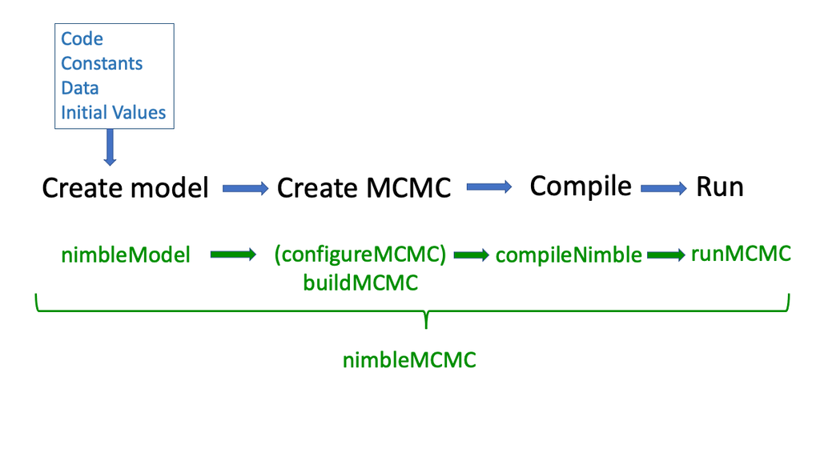

# Setup data, constants, and inits

```r
zinits <- matrix(2, nrow = nrow(y), ncol = ncol(y)) # create inits for unknown states
zdata <- matrix(NA, nrow = nrow(y), ncol = ncol(y)) # create data for known states
for(i in 1:nrow(zinits)) {
  known_alive <- range(which(y[i,] == 2))
  zinits[i, known_alive[1] : known_alive[2] ] <- NA # inits -> for known elements
  zdata[i, known_alive[1] : known_alive[2] ] <- 1   # data -> known values
}
dipper_constants <- list(N = nrow(y),
                         T = ncol(y),
                         first = first)
dipper_data <- list(y = y,
                    z = zdata)
dipper_inits <- function() list(phi = runif(1,0,1),
                                p = runif(1,0,1),
                                z = zinits)
head(dipper_data$z)     # data and inits have comlpementary
```

```
##      [,1] [,2] [,3] [,4] [,5] [,6] [,7]
## [1,]    1    1    1    1    1    1   NA
## [2,]    1    1    1    1    1   NA   NA
## [3,]    1    1    1    1   NA   NA   NA
## [4,]    1    1    1    1   NA   NA   NA
## [5,]    1    1    1    1    1    1   NA
## [6,]    1    1   NA   NA   NA   NA   NA
```

```r
head(dipper_inits()$z)  # NAs
```

```
##      [,1] [,2] [,3] [,4] [,5] [,6] [,7]
## [1,]   NA   NA   NA   NA   NA   NA    2
## [2,]   NA   NA   NA   NA   NA    2    2
## [3,]   NA   NA   NA   NA    2    2    2
## [4,]   NA   NA   NA   NA    2    2    2
## [5,]   NA   NA   NA   NA   NA   NA    2
## [6,]   NA   NA    2    2    2    2    2
```

# What are constants? What are data?

### Constants are values needed to define model relationships

- Index starting/ending values like `N`
- Constant indexing vectors for indexing data groupings (site, treatment, individual, time): `beta[ treatment[i] ]`.
- Constants must be provided when creating a model with `nimbleModel`.

### Data represents a flag on the role a node plays in the model

- E.g., data nodes shouldn’t be sampled in MCMC.
- Data *values* can be changed.
- Data can be provided when calling `nimbleModel` or later.

### Providing data and constants together.

- Data and constants can be provided together **as `constants`**.
- It would be slightly easier for BUGS/JAGS users to call this “data”, but that would blur the concepts.
- NIMBLE will usually disambiguate data and constants when they are provided together as `constants`.

### What are covariates and other non-parameters/non-observations?

- Covariates/predictors are neither parameters nor data in the sense of the likelihood.
- Covariates/predictors can be provided via `constants` if you don’t need to change them (often the case).
- Covariates/predictors can be provided via `data` or `inits` if you want to change them.
  - NIMBLE will not treat them as ‘data nodes’.

# Constants vs data for nested indexing

When values are grouped (particularly in irregular ways), we often have (potentially complicated) indexing.

Here is a model code snippet from a GLMM for disease occurrence in deer from different farms.

- `sex` is coded as 1 or 2 to index fixed-effect intercepts.
- `farm_ids` are coded as 1-24 for random-effect intercepts for data from 24 farms.
- Membership indices that are known in advance.
- **Provide known indexing vectors in `constants`.**
- Otherwise `nimble` allows that you (or your model) might change them later, which makes it handle them inefficiently (with unnecessary computation).

```r
nimbleCode({
  # ...incomplete code snippet...
  for(i in 1:2) sex_int[i] ~ dnorm(0, sd = 1000)  # prior for sex-specific intercepts
  for(i in 1:num_farms) farm_effect[i] ~ dnorm(0, sd = farm_sd) # priors for farm random effects
  farm_sd ~ dunif(0, 100)                         # prior for random effect std. dev.
  for(i in 1:num_animals) {
    logit(disease_probability[i]) <-              # logit link
      sex_int[ sex[i] ] +                         # nested indexing of sex-specific intercepts
      farm_effect[ farm_ids[i] ]                  # nested indexing of farm effects
    y[i] ~ dbern(disease_probability[i])          # "likelihood"
  }
  # ...
})
```

# Create a model

```r
dipper_model <- nimbleModel(code = dipper_code_dcat,
                            constants = dipper_constants,
                            data = dipper_data,     # data can be set later.
                            inits = dipper_inits()  # inits can be set later.
                            )                       # dimensions is also a useful argument.
```

```
## Defining model
```

```
## Building model
```

```
## Setting data and initial values
```

```
## Running calculate on model
##   [Note] Any error reports that follow may simply reflect missing values in model variables.
```

```
## Checking model sizes and dimensions
```

# Create an MCMC

```r
dipper_MCMCconf <- configureMCMC(dipper_model, monitors = c("phi", "p")) # can be skipped if you don't plan to customize
```

```
## ===== Monitors =====
## thin = 1: p, phi
## ===== Samplers =====
## RW sampler (2)
##   - phi
##   - p
## categorical sampler (613)
##   - z[]  (613 elements)
```

```r
dipper_MCMC <- buildMCMC(dipper_MCMCconf)
```

# Compile the model and MCMC

```r
C_dipper_model <- compileNimble(dipper_model)
```

```
## Compiling
##   [Note] This may take a minute.
##   [Note] Use 'showCompilerOutput = TRUE' to see C++ compilation details.
```

```r
C_dipper_MCMC <- compileNimble(dipper_MCMC, project = dipper_model)
```

```
## Compiling
##   [Note] This may take a minute.
##   [Note] Use 'showCompilerOutput = TRUE' to see C++ compilation details.
```

# Run the MCMC

```r
samples <- runMCMC(C_dipper_MCMC, niter = 10000, samplesAsCodaMCMC = TRUE)
```

```
## running chain 1...
## |-------------|-------------|-------------|-------------|
## |-------------------------------------------------------|
```

```r
summary(samples)
```

```
##
## Iterations = 1:10000
## Thinning interval = 1
## Number of chains = 1
## Sample size per chain = 10000
##
## 1. Empirical mean and standard deviation for each variable,
##    plus standard error of the mean:
##
##       Mean      SD  Naive SE Time-series SE
## p   0.8969 0.02908 0.0002908      0.0010871
## phi 0.5620 0.02552 0.0002552      0.0006998
##
## 2. Quantiles for each variable:
##
##       2.5%    25%    50%    75%  97.5%
## p   0.8343 0.8794 0.8991 0.9172 0.9455
## phi 0.5119 0.5437 0.5618 0.5795 0.6097
```

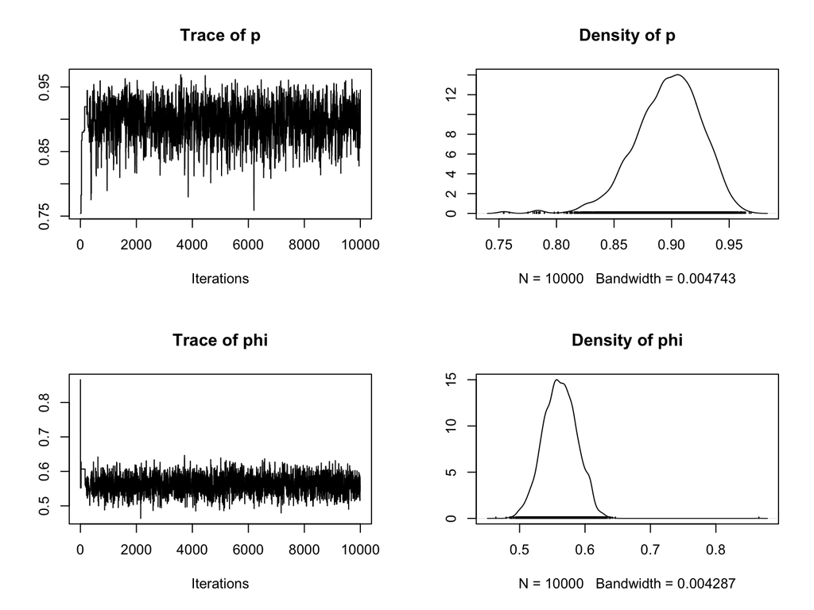

```r
plot(samples)
```

# How can I use the model in R?

```
## Defining model
```

```
## Building model
```

```
## Setting data and initial values
```

```
## Running calculate on model
##   [Note] Any error reports that follow may simply reflect missing values in model variables.
```

```
## Checking model sizes and dimensions
```

```r
class(dipper_model)[1]  # This is a reference class (S5) object
```

```
## [1] "dipper_cod_MID_1_modelClass_UID_2_UID_3"
```

```r
dipper_model$gamma           # Look at a model variable,
```

```
##           [,1]       [,2]
## [1,] 0.9291463 0.07085368
## [2,] 0.0000000 1.00000000
```

```r
dipper_model$y[1:2, ]        # or part of one.
```

```
##      year_1981 year_1982 year_1983 year_1984 year_1985 year_1986 year_1987
## [1,]         2         2         2         2         2         2         1
## [2,]         2         2         2         2         2         1         1
```

```r
dipper_model$isData('gamma') # Query what is data
```

```
## [1] FALSE FALSE
```

```r
dipper_model$getNodeNames()[1:10]  # Query what are the nodes (vertices) in the graph,
```

```
##  [1] "phi"           "p"             "gamma[2, 1:2]" "delta[1:2]"
##  [5] "omega[2, 1:2]" "gamma[1, 1:2]" "omega[1, 1:2]" "z[1, 1]"
##  [9] "z[2, 1]"       "z[3, 1]"
```

```r
dipper_model$getDependencies("z[1, 3]") # and what depends on what.
```

```
## [1] "z[1, 3]" "z[1, 4]" "y[1, 3]"
```

```r
dipper_model$calculate()     # Calculate the entire model. Return sum of log probabilities.
```

```
## [1] -806.6744
```

```r
dipper_model$calculate('z[1, 3]') # Calculate one or more nodes in the model.
```

```
## [1] -0.07348905
```

```r
dipper_model$calculate(dipper_model$getDependencies('z[1, 3]')) # Calculate based on model structure.
```

```
## [1] -1.273247
```

```r
dipper_model$simulate("y", includeData = TRUE) # Simulate new data
head(dipper_model$y)
```

```
##      year_1981 year_1982 year_1983 year_1984 year_1985 year_1986 year_1987
## [1,]         2         2         1         1         2         1         1
## [2,]         2         1         1         1         1         1         1
## [3,]         2         1         2         1         1         1         1
## [4,]         2         1         1         1         1         1         1
## [5,]         2         1         2         1         1         1         1
## [6,]         2         1         1         1         1         1         1
```

```r
dipper_model$calculate("y")   # Calculate new sum of log probabilities
```

```
## [1] -146.4428
```

# NIMBLE might insert nodes into your model!

These are called *lifted nodes*.

### Example 1: reparameterization

You give NIMBLE this:

```r
nimbleCode({
  tau <- 1E-0.6
  mu ~ dnorm(0, tau)
})
```

- NIMBLE defaults to parameterizations from **WinBUGS/OpenBUGS/JAGS, not R**.
- Default SD/Var/precision for `dnorm` is **precision** = 1/variance.
- NIMBLE converts this to a *canonical* parameterization for computations by treating it like this:

```r
nimbleCode({
  tau <- 1E-0.6
  some_long_name_created_by_nimble <- 1/sqrt(tau) # a lifted node
  mu ~ dnorm(0, sd = some_long_name_created_by_nimble)
})
```

Example 2: Lifted expressions

You give NIMBLE this:

```r
nimbleCode({
  for(i in 1:n) y[i] ~ dnorm(a + b*x[i], sd = sigma)
})
```

It treats it like this:

```r
nimbleCode({
  for(i in 1:n) {
    some_long_name_generated_by_nimble[i] <- a + b*x[i] # lifted nodes
    y ~ dnorm(some_long_name_generated_by_nimble[i], sd = sigma)
  })
```

# How can I use the MCMC configuration in R?

- Change the set of samplers that compose an MCMC algorithm.
- See `help(samplers)` for samplers built in to `nimble`.
- Default sampler assignments:
  - Conjugate (Gibbs) sampler when possible.
  - Special samplers for Bernoulli, categorical, Dirichlet, multinomial, CAR, BNP, possibly others.
  - Slice samplers for discrete distributions such as Poisson.
  - Adaptive random-walk Metropolis-Hastings samplers for other continuous distributions.
- MCMC efficiency = Effective sample size (mixing) / computation time
  - Both speed and mixing matter.
  - There is often a tradeoff between these.
- Some ways to customize samplers
  - Block (jointly) sample correlated dimensions.
  - Block samplers include adaptive random-walk Metropolis-Hastings, automated factor slice sampler, and elliptical slice sampler (special case for MVN).
  - Include multiple samplers that update slowly mixing nodes
  - Sample nodes such as standard deviations on a log scale (control parameter of adaptive random-walk Metropolis-Hastings (“RW”) sampler).
- Write your own sampler:
  - You don’t need to invent new MCMC theory in order to write useful samplers.
  - E.g., copy and modify our random-walk Metropolis-Hastings sampler to make proposals that respect model constraints or otherwise take advantage of model structure.
  - A good opportunity for new collaborations and new R packages.

```r
# These steps would be done before buildMCMC
dipper_MCMCconf$printSamplers("phi")
```

```
## [1] RW sampler: phi
```

```r
dipper_MCMCconf$removeSamplers("phi")
dipper_MCMCconf$addSampler("phi", type = "slice")
dipper_MCMCconf$printSamplers("phi")
```

```
## [615] slice sampler: phi
```

# How can I use uncompiled vs. compiled models and algorithms?

- An important and perhaps unfamiliar principle:
  - (Almost) everything can be run **uncompiled** (in R) or **compiled** (in C++).
- Uncompiled use of models and algorithms in R allows debugging.
  - Behavior is not always identical but is close.
  - Example: Error trapping will behave differently. Errors in C++ might not occur in R.

# Differences from NIMBLE to JAGS and/or BUGS

- See our [guide on converting from JAGS to NIMBLE](https://r-nimble.org/quick-guide-for-converting-from-jags-or-bugs-to-nimble)
- Wrap your model code in `nimbleCode({})` directly in R.
- Provide information about missing or empty indices:
  - Use `x[1:n, 1:m]` or
  - `x[,]` with `dimensions = list(x = c(n,m))`.
  - Do not use `x` without brackets (unless it is a scalar).

# Decide how much MCMC control you need:

- `nimbleMCMC` will do everything.
- `nimbleModel`, `configureMCMC`, `buildMCMC`, `compileNimble` and `runMCMC` give you more control.

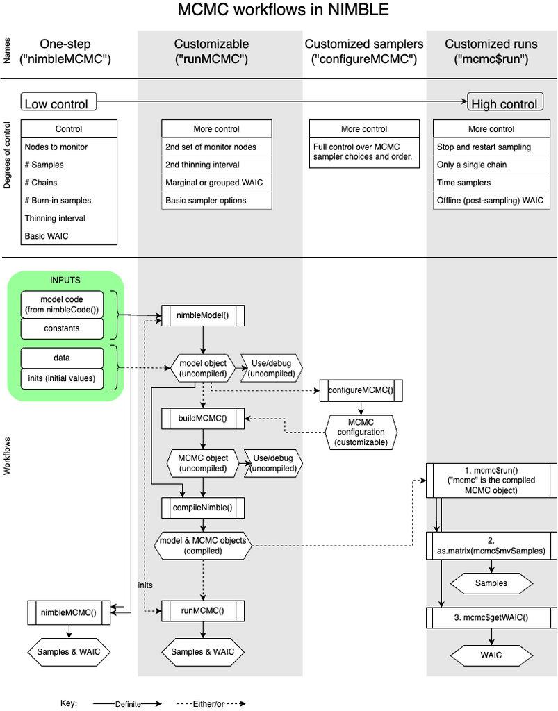

# Additional Resources

[NIMBLE User Manual](https://r-nimble.org/html_manual/cha-welcome-nimble.html)

[NIMBLE Cheat Sheet](https://r-nimble.org/cheatsheets/NimbleCheatSheet.pdf)